# What’s Next (Text Prediction Application)

author: Omayma Said date: 30 Dec 2016 autosize: true

# About What’s Next

**What’s Next** is a Shiny application that uses NLP models for text prediction. It provides two options as shown in the screenshots:

- **Next Word Prediction**
- **Trigram Model Probability**

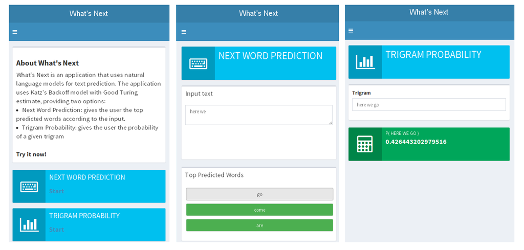

Fig.1-What’s Next Tabs

-**What’s Next** on Shinyapp.io: [HERE](https://omaymas.shinyapps.io/What_is_next/)  
-Created by OmaymaS

# Getting Started With What’s Next

**Next Word Prediction**

Enter text to get the top-3 predicted words based on your input. *(similar to mobile phones and other gadgets’ keyboards)*.

| Input | W1 | W2 | W3 |
| --- | --- | --- | --- |
| here we go | to | on | again |
| I’d like to see | you | the | what |
| I’d like to say thanks for the | follow | first | RT |

**Trigram Model Probaibiliy**

Enter three words *(Trigram)* to get its probability

| Input | Output |
| --- | --- |
| here we go | P(Here we go) |
| and we can do the | P(can do the) |
| the first | Not found in the trigram model |

- If Input>3 word, only the last 3 are considered.
- If Input<3 word, or if the trigram is not found in our model, the user gets a message “Not found in the trigram model

# Technical Details (Katz’s backoff Model) 1/2

Using 70% of the given dataset:

- data was cleaned removing symbols, profanity, extra spaces, non-latin characters and certain words/letters.
- unigram, bigram and trigram datatables were generated with the count of each entry.

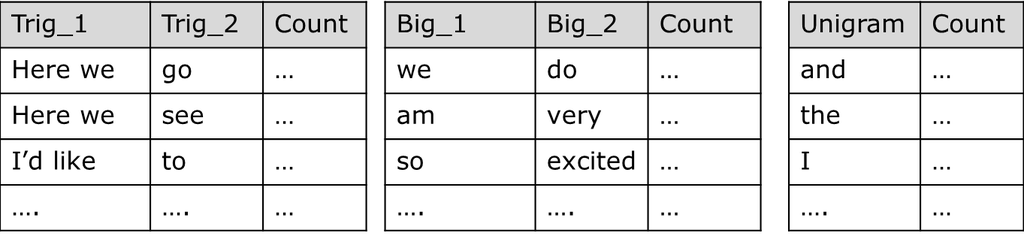

- Good-Turing discounts were calculated for Nr<=5 *(Nr: frequency of frequency).*
- Probability is calculated using Katz’s Backoff model as shown in the example in Fig-2.

**Advantage**: *Reactive*

**Tradeoffs**: *Accuracy Vs. Speed*

**Areas for Improvement**: *Application Startup Speed*

# Technical Details (Katz’s backoff Model) 2/2

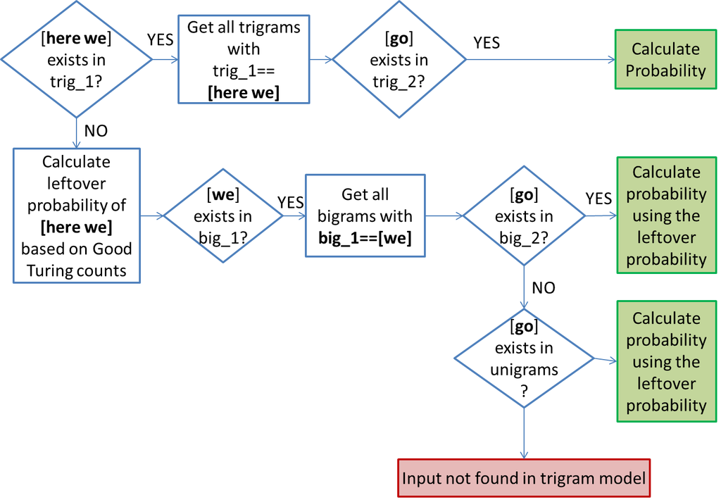

Fig.2- P(here we go) using Katz’s Backoff